# Mental Health & Predictable Work Schedules

Schedule Volatility, Front-loading, and Household Wellbeing

Jingyao

二月 23, 2026

## 0.1 Import Data

```r
data_path <- "C:/Users/jingy/Dropbox/VIP/09. Main study/09. Data/20. Generated/simon_analysis/30_merged_panel-hh_id-period.dta"
if (!file.exists(data_path)) stop("Error: Data file not found at: ", data_path)
cat("Loading data from:", data_path, "\n")
data <- read_dta(data_path)
cat("Data loaded successfully!\n")
cat("Dimensions:", nrow(data), "rows x", ncol(data), "columns\n\n")
```

## 0.2 Filter and Prepare Data

```r
data_analysis <- data %>%
    mutate(
        group_label = case_when(
            control == 1 ~ "Control",
            predictable == 1 & period == 0 ~ "Baseline",
            predictable == 1 & high_draw == 1 ~ "High Draw",
            predictable == 1 & high_draw == 0 ~ "Low Draw",
            TRUE ~ "Unknown"
        ),
        period_label = case_when(
            period == 0 ~ "Period 0 (Baseline)",
            TRUE ~ paste0("Period ", period)
        )
    )

cat("Dataset with treatment and control groups:\n")
```

```
## Dataset with treatment and control groups:
```

```r
cat("  Total observations:", nrow(data_analysis), "\n")
```

```
##   Total observations: 15904
```

```r
cat("  Unique households:", length(unique(data_analysis$hh_id)), "\n")
```

```
##   Unique households: 2272
```

```r
cat("  Periods included:", sort(unique(data_analysis$period)), "\n\n")
```

```
##   Periods included: 0 1 2 3 4 5 6
```

```r
cat("Observations by period and group:\n")
```

```
## Observations by period and group:
```

```r
data_analysis %>%
    count(period, group_label) %>%
    arrange(period, group_label) %>%
    print()
```

```
## # A tibble: 27 × 3
##    period       group_label     n
##    <dbl+lbl>    <chr>       <int>
##  1 0 [Baseline] Baseline      402
##  2 0 [Baseline] Control       401
##  3 0 [Baseline] Unknown      1469
##  4 1            Control       401
##  5 1            High Draw     201
##  6 1            Low Draw      201
##  7 1            Unknown      1469
##  8 2            Control       401
##  9 2            High Draw     201
## 10 2            Low Draw      201
## # ℹ 17 more rows
```

## 0.3 Schedule Categorization

```r
cat("=== CREATING SCHEDULE CATEGORIES ===\n\n")
```

```
## === CREATING SCHEDULE CATEGORIES ===
```

```r
schedule_chars <- data %>%
    filter(predictable == 1, period > 0) %>%
    arrange(hh_id, period) %>%
    group_by(schedule) %>%
    summarise(
        prop_high = mean(high_draw, na.rm = TRUE),
        n_switches = mean(
            tapply(high_draw, hh_id, function(x) sum(abs(diff(x)), na.rm = TRUE)),
            na.rm = TRUE
        ),
        front_loading = mean(
            tapply(seq_along(high_draw), hh_id, function(idx) {
                hd <- high_draw[idx]
                w <- rev(seq_along(hd))
                weighted.mean(hd, w = w, na.rm = TRUE)
            }),
            na.rm = TRUE
        ),
        .groups = "drop"
    ) %>%
    mutate(
        volatility_cat = case_when(
            n_switches <= 1 ~ "Low Volatility (<=1 switch)",
            n_switches <= 3 ~ "Medium Volatility (2-3 switches)",
            TRUE ~ "High Volatility (>=4 switches)"
        ),
        timing_cat = case_when(
            front_loading > 0.55 ~ "Front-loaded (High draws early)",
            front_loading < 0.45 ~ "Back-loaded (High draws late)",
            TRUE ~ "Balanced timing"
        ),
        vol_fl = n_switches * front_loading,
        vol_fl_grp = cut(vol_fl,
            breaks = quantile(vol_fl, probs = c(0, 1 / 3, 2 / 3, 1), na.rm = TRUE),
            labels = c("Low composite", "Medium composite", "High composite"),
            include.lowest = TRUE
        )
    )

cat("Schedule characteristics (sorted by vol_fl):\n")
```

```
## Schedule characteristics (sorted by vol_fl):
```

```r
schedule_chars %>%
    select(schedule, n_switches, front_loading, vol_fl, vol_fl_grp, volatility_cat, timing_cat) %>%
    arrange(vol_fl) %>%
    print(n = Inf)
```

```
## # A tibble: 20 × 7
##    schedule n_switches front_loading vol_fl vol_fl_grp volatility_cat timing_cat
##    <chr>         <dbl>         <dbl>  <dbl> <fct>      <chr>          <chr>
##  1 LLLHHH            1         0.286  0.286 Low compo… Low Volatilit… Back-load…
##  2 HHHLLL            1         0.714  0.714 Low compo… Low Volatilit… Front-loa…
##  3 HLLLHH            2         0.429  0.857 Low compo… Medium Volati… Back-load…
##  4 LLHHHL            2         0.429  0.857 Low compo… Medium Volati… Back-load…
##  5 LLHLHH            3         0.333  1     Low compo… Medium Volati… Back-load…
##  6 HHLLLH            2         0.571  1.14  Low compo… Medium Volati… Front-loa…
##  7 LHHHLL            2         0.571  1.14  Low compo… Medium Volati… Front-loa…
##  8 LHLLHH            3         0.381  1.14  Low compo… Medium Volati… Back-load…
##  9 LLHHLH            3         0.381  1.14  Low compo… Medium Volati… Back-load…
## 10 LHHLLH            3         0.476  1.43  Medium co… Medium Volati… Balanced …
## 11 HLLHHL            3         0.524  1.57  Medium co… Medium Volati… Balanced …
## 12 HHLLHL            3         0.619  1.86  Medium co… Medium Volati… Front-loa…
## 13 HLHHLL            3         0.619  1.86  Medium co… Medium Volati… Front-loa…
## 14 HLLHLH            4         0.476  1.90  High comp… High Volatili… Balanced …
## 15 LHLHHL            4         0.476  1.90  High comp… High Volatili… Balanced …
## 16 HHLHLL            3         0.667  2     High comp… Medium Volati… Front-loa…
## 17 HLHLLH            4         0.524  2.10  High comp… High Volatili… Balanced …
## 18 LHHLHL            4         0.524  2.10  High comp… High Volatili… Balanced …
## 19 LHLHLH            5         0.429  2.14  High comp… High Volatili… Back-load…
## 20 HLHLHL            5         0.571  2.86  High comp… High Volatili… Front-loa…
```

```r
data_analysis <- data_analysis %>%
    left_join(
        schedule_chars %>%
            select(schedule, volatility_cat, timing_cat, n_switches, front_loading, vol_fl, vol_fl_grp),
        by = "schedule"
    )

cat("\nSchedule categories merged into data_analysis.\n")
```

```
##
## Schedule categories merged into data_analysis.
```

```r
cat("  vol_fl range:", round(range(schedule_chars$vol_fl, na.rm = TRUE), 3), "\n")
```

```
##   vol_fl range: 0.286 2.857
```

```r
cat("  vol_fl_grp levels:", paste(levels(schedule_chars$vol_fl_grp), collapse = ", "), "\n")
```

```
##   vol_fl_grp levels: Low composite, Medium composite, High composite
```

# 1 INTRA-CLASS CORRELATION (ICC) ANALYSIS

## 1.1 ICC by Raw Schedule and by Category

```r
cat("Calculating ICC across grouping dimensions...\n\n")
```

Calculating ICC across grouping dimensions…

```r
icc_data <- data_analysis %>% filter(predictable == 1, period > 0)

icc_outcomes <- c(
    "phq2_z", "gad2_z",
    "total_income_99", "total_consumption_99", "food_consumption_total_99",
    "asset_net_99", "svg_savings_flow_99",
    "days_worked", "working_adults_corrected"
)

outcome_labels <- c(
    phq2_z = "Depression (PHQ-2)",
    gad2_z = "Anxiety (GAD-2)",
    total_income_99 = "Total Income",
    total_consumption_99 = "Total Consumption",
    food_consumption_total_99 = "Food Consumption",
    asset_net_99 = "Net Asset Accumulation",
    svg_savings_flow_99 = "Savings Flow",
    days_worked = "Days Worked",
    working_adults_corrected = "Working Adults"
)

calc_icc <- function(outcome, group_var, data) {
    if (!outcome %in% names(data) || !group_var %in% names(data)) {
        return(NA_real_)
    }
    sub <- data[!is.na(data[[outcome]]) & !is.na(data[[group_var]]), ]
    if (nrow(sub) < 10 || sd(sub[[outcome]], na.rm = TRUE) == 0) {
        return(NA_real_)
    }
    tryCatch(
        {
            m <- lmer(as.formula(paste0(outcome, " ~ 1 + (1 | ", group_var, ")")),
                data = sub, REML = TRUE
            )
            vc <- as.data.frame(VarCorr(m))
            var_grp <- vc$vcov[vc$grp == group_var]
            var_res <- vc$vcov[vc$grp == "Residual"]
            var_grp / (var_grp + var_res)
        },
        error = function(e) NA_real_
    )
}

grouping_vars <- c("schedule", "volatility_cat", "timing_cat", "vol_fl_grp")
grouping_labels <- c(
    schedule       = "Raw Schedule (20 groups)",
    volatility_cat = "Volatility (# switches)",
    timing_cat     = "Timing (Front vs Back)",
    vol_fl_grp     = "Volatility x Front-loading (composite)"
)

icc_table <- expand.grid(
    Outcome = icc_outcomes, Grouping = grouping_vars,
    stringsAsFactors = FALSE
) %>%
    rowwise() %>%
    mutate(ICC = calc_icc(Outcome, Grouping, icc_data)) %>%
    ungroup() %>%
    mutate(
        OutcomeLabel = outcome_labels[Outcome],
        GroupingLabel = grouping_labels[Grouping],
        Category = case_when(
            Outcome %in% c("phq2_z", "gad2_z") ~ "Mental Health",
            Outcome %in% c("days_worked", "working_adults_corrected") ~ "Labor",
            TRUE ~ "Financial"
        )
    ) %>%
    arrange(Category, Outcome, Grouping) %>%
    select(Category, OutcomeLabel, GroupingLabel, ICC)

icc_wide <- icc_table %>% tidyr::pivot_wider(names_from = GroupingLabel, values_from = ICC)

icc_wide %>%
    gt() %>%
    tab_header(
        title    = "ICC by Outcome and Schedule Grouping Dimension",
        subtitle = "How much variation is explained by each way of categorizing the 20 schedules?"
    ) %>%
    fmt_percent(columns = where(is.numeric), decimals = 2) %>%
    cols_label(Category = "Category", OutcomeLabel = "Outcome") %>%
    tab_style(style = cell_text(weight = "bold"), locations = cells_column_labels()) %>%
    tab_spanner(label = "Schedule Grouping Dimension", columns = 3:6) %>%
    tab_options(table.width = pct(95)) %>%
    print()
```

ICC by Outcome and Schedule Grouping Dimension

How much variation is explained by each way of categorizing the 20 schedules?

| Category | Outcome | Schedule Grouping Dimension Raw Schedule (20 groups) | Schedule Grouping Dimension Timing (Front vs Back) | Schedule Grouping Dimension Volatility x Front-loading (composite) | Schedule Grouping Dimension Volatility (# switches) |
| --- | --- | --- | --- | --- | --- |
| Financial | Net Asset Accumulation | 0.06% | 0.00% | 0.00% | 0.00% |
| Financial | Food Consumption | 1.58% | 0.05% | 0.06% | 0.06% |
| Financial | Savings Flow | 0.00% | 0.00% | 0.00% | 0.00% |
| Financial | Total Consumption | 1.58% | 0.12% | 0.03% | 0.13% |
| Financial | Total Income | 0.77% | 0.00% | 0.57% | 0.37% |
| Labor | Days Worked | 0.88% | 0.09% | 0.00% | 0.00% |
| Labor | Working Adults | 0.24% | 0.00% | 0.00% | 0.00% |
| Mental Health | Anxiety (GAD-2) | 0.31% | 0.12% | 0.11% | 0.27% |
| Mental Health | Depression (PHQ-2) | 0.19% | 0.00% | 0.00% | 0.04% |

```r
cat("\nInterpretation: Compare ICC across columns for each outcome row.\n")
```

Interpretation: Compare ICC across columns for each outcome row.

```r
cat("Higher ICC for 'Volatility x Front-loading' than 'Raw Schedule' means\n")
```

Higher ICC for ‘Volatility x Front-loading’ than ‘Raw Schedule’ means

```r
cat("the composite index explains *more* variation than just the schedule ID.\n")
```

the composite index explains *more* variation than just the schedule ID.

# 2 SCHEDULE CHARACTERISTICS REGRESSION

## 2.1 How `front_loading` is Constructed

The `front_loading` variable measures **when** within the 6-period treatment window the High draws are concentrated. It is a **position-weighted mean** of the draw sequence ($w_t = 7 - t$, so period 1 gets weight 6, period 6 gets weight 1).

## 2.2 Composite Index: `vol_fl = n_switches x front_loading`

`vol_fl` captures the **joint** schedule shape. A high value means many H/L switches **and** the High draws are concentrated early — the most disruptive combination. We standardise it (mean 0, SD 1) before regression.

```r
data_reg <- data_analysis %>%
    filter(predictable == 1, period > 0) %>%
    mutate(vol_fl_std = as.numeric(scale(vol_fl)))

reg_outcomes <- c(
    "phq2_z", "gad2_z",
    "total_income_99", "total_consumption_99", "food_consumption_total_99",
    "asset_net_99", "svg_savings_flow_99",
    "days_worked", "working_adults_corrected"
)

reg_labels <- c(
    phq2_z                    = "Depression (PHQ-2)",
    gad2_z                    = "Anxiety (GAD-2)",
    total_income_99           = "Total Income",
    total_consumption_99      = "Total Consumption",
    food_consumption_total_99 = "Food Consumption",
    asset_net_99              = "Net Assets",
    svg_savings_flow_99       = "Savings Flow",
    days_worked               = "Days Worked",
    working_adults_corrected  = "Working Adults"
)

coef_map <- c("vol_fl_std" = "Volatility x Front-loading (composite, std.)")

outcome_dict <- data.frame(
    Abbreviation = reg_outcomes,
    Label = unname(reg_labels[reg_outcomes]),
    Domain = c(
        "Mental Health", "Mental Health",
        "Income & Consumption", "Income & Consumption", "Income & Consumption",
        "Assets & Savings", "Assets & Savings",
        "Labor", "Labor"
    ),
    Description = c(
        "Sum of 2 PHQ-9 depression items, standardised (z-score)",
        "Sum of 2 GAD-7 anxiety items, standardised (z-score)",
        "Total household income received in the period (99th pct. winsorized)",
        "Total household consumption expenditure (99th pct. winsorized)",
        "Expenditure on food items only (99th pct. winsorized)",
        "Net value of assets accumulated: purchases minus sales (99th pct. winsorized)",
        "Net savings flow into formal/informal savings accounts (99th pct. winsorized)",
        "Total days worked by all household members in the period",
        "Number of adults in the household who worked at least 1 day"
    ),
    stringsAsFactors = FALSE
)

run_pooled <- function(outcome, data) {
    if (!outcome %in% names(data)) {
        return(NULL)
    }
    fml <- as.formula(paste0(outcome, " ~ vol_fl_std | period"))
    tryCatch(feols(fml, cluster = ~hh_id, data = data), error = function(e) NULL)
}

make_models <- function(data) {
    mods <- Filter(
        Negate(is.null),
        setNames(lapply(reg_outcomes, run_pooled, data = data), reg_outcomes)
    )
    setNames(mods, reg_labels[names(mods)])
}

models_p5 <- make_models(data_reg %>% filter(period <= 5))
models_p6 <- make_models(data_reg)

print_reg_table <- function(models, title_str) {
    modelsummary(models,
        coef_map = coef_map, fmt = 3,
        stars = c("*" = 0.1, "**" = 0.05, "***" = 0.01),
        gof_omit = "AIC|BIC|Log|RMSE|Std",
        title = title_str,
        notes = "Predictable group only. Period FE. SEs clustered at household.",
        output = "html"
    )
}

print_dict_table <- function() {
    outcome_dict %>%
        select(Domain, Label, Abbreviation, Description) %>%
        gt() %>%
        cols_label(
            Domain = "Domain", Label = "Label in table",
            Abbreviation = "Variable name", Description = "What it measures"
        ) %>%
        tab_style(style = cell_text(weight = "bold"), locations = cells_column_labels()) %>%
        tab_options(table.width = pct(100)) %>%
        print()
}

cat("### Pooled Regression: Periods 1-5\n\n")
```

### 2.2.1 Pooled Regression: Periods 1-5

```r
print_reg_table(models_p5, "Composite Schedule Index (vol_fl) -- Pooled, Periods 1-5")
```

Composite Schedule Index (vol_fl) -- Pooled, Periods 1-5

|  | Depression (PHQ-2) | Anxiety (GAD-2) | Total Income | Total Consumption | Food Consumption | Net Assets | Savings Flow | Days Worked | Working Adults |
| --- | --- | --- | --- | --- | --- | --- | --- | --- | --- |
| Volatility x Front-loading (composite, std.) | 0.008 | 0.033 | 18.735 | -4.530 | -4.972 | -6.236 | -7.461 | -0.096 | -0.005 |
|  | (0.025) | (0.027) | (11.372) | (15.583) | (12.273) | (3.803) | (6.798) | (0.146) | (0.017) |
| Num.Obs. | 1850 | 1850 | 1850 | 1850 | 1850 | 1850 | 1722 | 1850 | 1850 |
| R2 | 0.008 | 0.025 | 0.002 | 0.103 | 0.092 | 0.010 | 0.001 | 0.045 | 0.010 |
| R2 Adj. | 0.006 | 0.022 | -0.000 | 0.100 | 0.090 | 0.008 | -0.002 | 0.043 | 0.007 |
| R2 Within | 0.000 | 0.001 | 0.002 | 0.000 | 0.000 | 0.002 | 0.000 | 0.000 | 0.000 |
| R2 Within Adj. | -0.000 | 0.001 | 0.002 | -0.000 | -0.000 | 0.002 | -0.000 | -0.000 | -0.000 |
| FE: period | X | X | X | X | X | X | X | X | X |

* p < 0.1, ** p < 0.05, *** p < 0.01  
Predictable group only. Period FE. SEs clustered at household.

```r
cat("\n\n**Outcome variable reference:**\n\n")
```

**Outcome variable reference:**

```r
print_dict_table()
```

| Domain | Label in table | Variable name | What it measures |
| --- | --- | --- | --- |
| Mental Health | Depression (PHQ-2) | phq2_z | Sum of 2 PHQ-9 depression items, standardised (z-score) |
| Mental Health | Anxiety (GAD-2) | gad2_z | Sum of 2 GAD-7 anxiety items, standardised (z-score) |
| Income & Consumption | Total Income | total_income_99 | Total household income received in the period (99th pct. winsorized) |
| Income & Consumption | Total Consumption | total_consumption_99 | Total household consumption expenditure (99th pct. winsorized) |
| Income & Consumption | Food Consumption | food_consumption_total_99 | Expenditure on food items only (99th pct. winsorized) |
| Assets & Savings | Net Assets | asset_net_99 | Net value of assets accumulated: purchases minus sales (99th pct. winsorized) |
| Assets & Savings | Savings Flow | svg_savings_flow_99 | Net savings flow into formal/informal savings accounts (99th pct. winsorized) |
| Labor | Days Worked | days_worked | Total days worked by all household members in the period |
| Labor | Working Adults | working_adults_corrected | Number of adults in the household who worked at least 1 day |

```r
cat("\n\n### Pooled Regression: Periods 1-6\n\n")
```

### 2.2.2 Pooled Regression: Periods 1-6

```r
print_reg_table(models_p6, "Composite Schedule Index (vol_fl) -- Pooled, Periods 1-6")
```

Composite Schedule Index (vol_fl) -- Pooled, Periods 1-6

|  | Depression (PHQ-2) | Anxiety (GAD-2) | Total Income | Total Consumption | Food Consumption | Net Assets | Savings Flow | Days Worked | Working Adults |
| --- | --- | --- | --- | --- | --- | --- | --- | --- | --- |
| Volatility x Front-loading (composite, std.) | 0.000 | 0.030 | 27.789** | -6.014 | -7.544 | -4.903 | -8.343 | -0.073 | -0.004 |
|  | (0.024) | (0.026) | (12.066) | (17.583) | (12.706) | (3.713) | (5.898) | (0.135) | (0.017) |
| Num.Obs. | 2239 | 2239 | 2246 | 2246 | 2246 | 2246 | 2092 | 2246 | 2246 |
| R2 | 0.030 | 0.049 | 0.025 | 0.110 | 0.076 | 0.020 | 0.002 | 0.039 | 0.051 |
| R2 Adj. | 0.028 | 0.046 | 0.023 | 0.108 | 0.074 | 0.017 | -0.000 | 0.037 | 0.049 |
| R2 Within | 0.000 | 0.001 | 0.004 | 0.000 | 0.000 | 0.001 | 0.000 | 0.000 | 0.000 |
| R2 Within Adj. | -0.000 | 0.000 | 0.003 | -0.000 | -0.000 | 0.000 | -0.000 | -0.000 | -0.000 |
| FE: period | X | X | X | X | X | X | X | X | X |

* p < 0.1, ** p < 0.05, *** p < 0.01  
Predictable group only. Period FE. SEs clustered at household.

```r
cat("\n\n**Outcome variable reference:**\n\n")
```

**Outcome variable reference:**

```r
print_dict_table()
```

| Domain | Label in table | Variable name | What it measures |
| --- | --- | --- | --- |
| Mental Health | Depression (PHQ-2) | phq2_z | Sum of 2 PHQ-9 depression items, standardised (z-score) |
| Mental Health | Anxiety (GAD-2) | gad2_z | Sum of 2 GAD-7 anxiety items, standardised (z-score) |
| Income & Consumption | Total Income | total_income_99 | Total household income received in the period (99th pct. winsorized) |
| Income & Consumption | Total Consumption | total_consumption_99 | Total household consumption expenditure (99th pct. winsorized) |
| Income & Consumption | Food Consumption | food_consumption_total_99 | Expenditure on food items only (99th pct. winsorized) |
| Assets & Savings | Net Assets | asset_net_99 | Net value of assets accumulated: purchases minus sales (99th pct. winsorized) |
| Assets & Savings | Savings Flow | svg_savings_flow_99 | Net savings flow into formal/informal savings accounts (99th pct. winsorized) |
| Labor | Days Worked | days_worked | Total days worked by all household members in the period |
| Labor | Working Adults | working_adults_corrected | Number of adults in the household who worked at least 1 day |

```r
cat("\n\n**Coefficient interpretation:** 1 SD increase in vol_fl (more volatile AND\n")
```

**Coefficient interpretation:** 1 SD increase in vol_fl (more volatile AND

```r
cat("front-loaded schedule) is associated with this change in the outcome.\n")
```

front-loaded schedule) is associated with this change in the outcome.

```r
cat("Positive on PHQ-2/GAD-2 = worse mental health.\n\n")
```

Positive on PHQ-2/GAD-2 = worse mental health.

# 3 DYNAMIC EFFECTS BY PERIOD

The period-by-period coefficient plot shows whether the effect of `vol_fl` **accumulates, fades, or reverses** across the 6 treatment periods. Each point = OLS coefficient from a cross-sectional regression within that period. Shaded bands = 95% CI. **Each domain has its own fixed y-axis.**

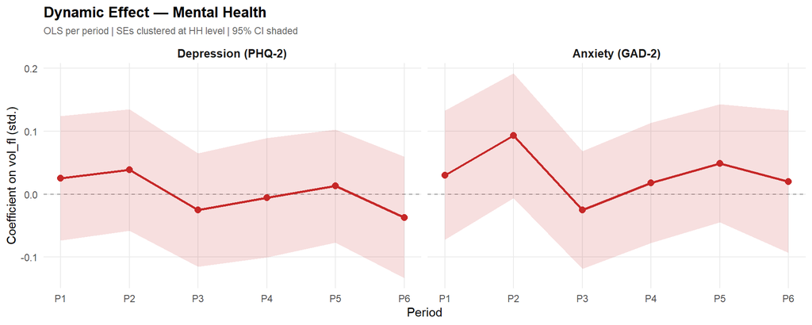

```r
run_by_period <- function(outcome, period_val, data) {
    sub <- data %>% filter(period == period_val)
    if (!outcome %in% names(sub) || nrow(sub) < 10) {
        return(NULL)
    }
    fml <- as.formula(paste0(outcome, " ~ vol_fl_std"))
    # Cluster at HH level: schedule randomized at HH level, so this is
    # the correct unit. In a cross-section this equals HC robust SEs.
    tryCatch(feols(fml, cluster = ~hh_id, data = sub),
        error = function(e) NULL
    )
}

dyn_results <- lapply(reg_outcomes, function(outcome) {
    lapply(1:6, function(p) {
        m <- run_by_period(outcome, p, data_reg)
        if (is.null(m)) {
            return(NULL)
        }
        b <- coef(m)["vol_fl_std"]
        se <- sqrt(vcov(m)["vol_fl_std", "vol_fl_std"])
        data.frame(
            outcome = outcome, period = p, coef = b, se = se,
            stringsAsFactors = FALSE
        )
    }) %>% dplyr::bind_rows()
}) %>%
    dplyr::bind_rows() %>%
    mutate(
        OutcomeLabel = factor(reg_labels[outcome], levels = reg_labels[reg_outcomes]),
        Domain = case_when(
            outcome %in% c("phq2_z", "gad2_z") ~ "Mental Health",
            outcome %in% c("days_worked", "working_adults_corrected") ~ "Labor",
            outcome %in% c("asset_net_99", "svg_savings_flow_99") ~ "Assets & Savings",
            TRUE ~ "Income & Consumption"
        ),
        lo95 = coef - 1.96 * se,
        hi95 = coef + 1.96 * se
    )

plot_domain <- function(domain_name, color_val, ncols = 2) {
    df <- dyn_results %>% filter(Domain == domain_name)
    ggplot(df, aes(x = period, y = coef)) +
        geom_hline(yintercept = 0, linetype = "dashed", color = "gray60", linewidth = 0.4) +
        geom_ribbon(aes(ymin = lo95, ymax = hi95), fill = color_val, alpha = 0.15) +
        geom_line(color = color_val, linewidth = 0.9) +
        geom_point(color = color_val, size = 2.5) +
        scale_x_continuous(breaks = 1:6, labels = paste0("P", 1:6)) +
        facet_wrap(~OutcomeLabel, scales = "fixed", ncol = ncols) +
        labs(
            title = paste0("Dynamic Effect — ", domain_name),
            subtitle = "OLS per period | SEs clustered at HH level | 95% CI shaded",
            x = "Period", y = "Coefficient on vol_fl (std.)"
        ) +
        theme_minimal(base_size = 11) +
        theme(
            strip.text       = element_text(face = "bold", size = 10),
            panel.grid.minor = element_blank(),
            plot.title       = element_text(face = "bold"),
            plot.subtitle    = element_text(size = 8.5, color = "gray40")
        )
}

plot_domain("Mental Health", "#C62828", ncols = 2)
```

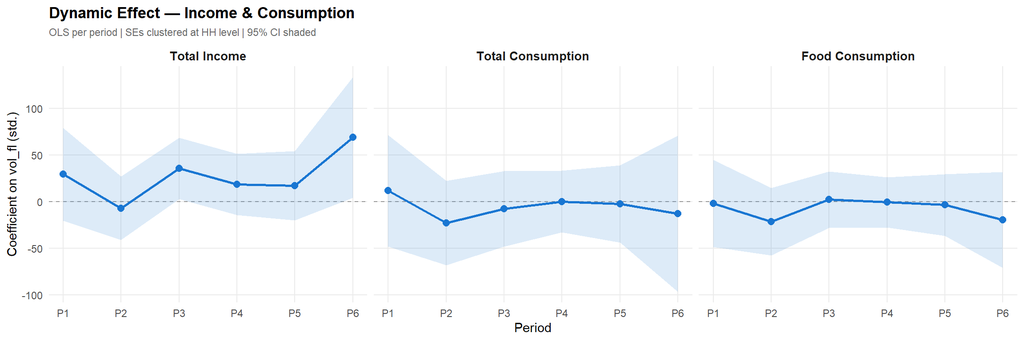

```r
plot_domain("Income & Consumption", "#1976D2", ncols = 3)
```

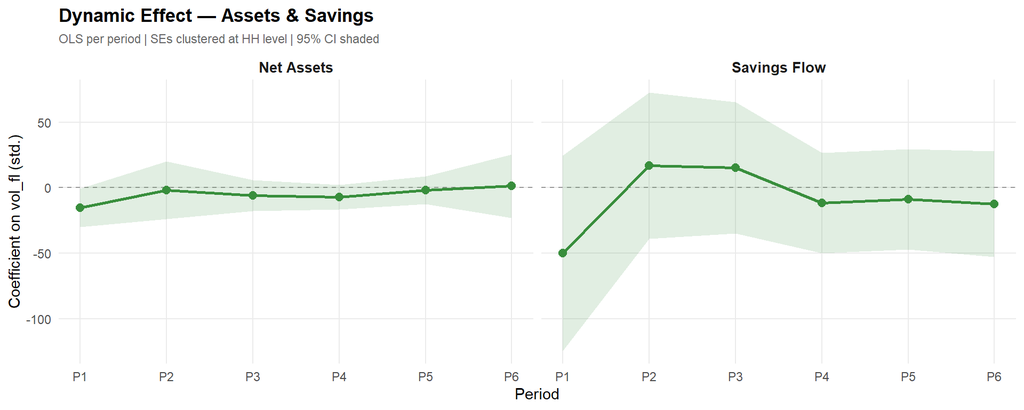

```r
plot_domain("Assets & Savings", "#388E3C", ncols = 2)
```

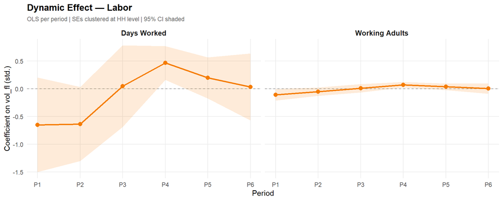

```r
plot_domain("Labor", "#F57C00", ncols = 2)
```

# 4 MENTAL HEALTH TRAJECTORIES BY SCHEDULE

Each of the 20 predictable schedules is plotted across periods 1–6. **Each row shows a schedule (left panel) next to its H↔︎L complement (right panel)**, so you can directly compare timing-flipped patterns. Rows are sorted by the maximum composite `vol_fl` of the pair (lowest pair at top).

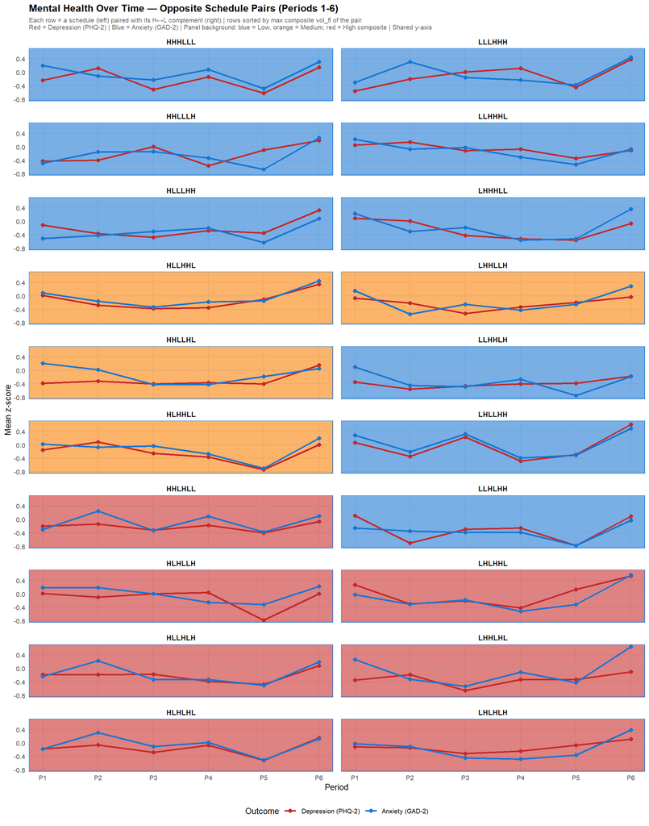

```r
# ── Mean MH per schedule x period ────────────────────────────────────────────
mh_sched <- data_analysis %>%
    filter(predictable == 1, period >= 1) %>%
    group_by(schedule, period, vol_fl_grp, vol_fl) %>%
    summarise(
        phq2 = mean(phq2_z, na.rm = TRUE),
        gad2 = mean(gad2_z, na.rm = TRUE),
        .groups = "drop"
    ) %>%
    tidyr::pivot_longer(
        cols = c(phq2, gad2),
        names_to = "outcome",
        values_to = "mean_z"
    ) %>%
    mutate(
        OutcomeLabel = ifelse(outcome == "phq2",
            "Depression (PHQ-2)", "Anxiety (GAD-2)"
        ),
        OutcomeLabel = factor(OutcomeLabel,
            levels = c("Depression (PHQ-2)", "Anxiety (GAD-2)")
        )
    )

# ── Build opposite pairs: flip H <-> L in schedule name ──────────────────────
# All C(6,3)=20 sequences of 3H+3L are in the data, so every complement exists.
flip_sched <- function(s) chartr("HL", "LH", s)

sched_meta <- mh_sched %>%
    distinct(schedule, vol_fl, vol_fl_grp) %>%
    mutate(complement = flip_sched(schedule))

# Use lexicographically smaller string as the canonical "A" of each pair
pairs <- sched_meta %>%
    filter(schedule < complement) %>%
    left_join(
        sched_meta %>% select(schedule, vol_fl_comp = vol_fl),
        by = c("complement" = "schedule")
    ) %>%
    mutate(pair_max_vol = pmax(vol_fl, vol_fl_comp)) %>%
    arrange(pair_max_vol) %>%
    mutate(pair_idx = row_number())

# Interleave: A (col 1) then complement (col 2) per pair row
ordered_scheds <- pairs %>%
    select(pair_idx, sched_A = schedule, sched_B = complement) %>%
    tidyr::pivot_longer(
        cols = c(sched_A, sched_B),
        names_to = "col", values_to = "schedule"
    ) %>%
    arrange(pair_idx, col) %>%
    pull(schedule)

mh_sched <- mh_sched %>%
    mutate(schedule_f = factor(schedule, levels = ordered_scheds))

# ── Shared y-axis across all 20 panels ───────────────────────────────────────
y_lim <- range(mh_sched$mean_z, na.rm = TRUE)

# ── Plot: ncol=2 so each pair falls on the same row ──────────────────────────
ggplot(
    mh_sched,
    aes(x = period, y = mean_z, color = OutcomeLabel, group = OutcomeLabel)
) +
    geom_rect(aes(fill = vol_fl_grp),
        xmin = -Inf, xmax = Inf, ymin = -Inf, ymax = Inf,
        alpha = 0.07, show.legend = FALSE
    ) +
    geom_hline(yintercept = 0, linetype = "dashed", color = "gray70", linewidth = 0.3) +
    geom_line(linewidth = 0.9) +
    geom_point(size = 2) +
    coord_cartesian(ylim = y_lim) +
    scale_x_continuous(breaks = 1:6, labels = paste0("P", 1:6)) +
    scale_color_manual(
        values = c(
            "Depression (PHQ-2)" = "#C62828",
            "Anxiety (GAD-2)" = "#1976D2"
        ),
        name = "Outcome"
    ) +
    scale_fill_manual(
        values = c(
            "Low composite" = "#1976D2",
            "Medium composite" = "#F57C00",
            "High composite" = "#C62828"
        ),
        guide = "none"
    ) +
    facet_wrap(~schedule_f, ncol = 2) +
    labs(
        title = "Mental Health Over Time — Opposite Schedule Pairs (Periods 1-6)",
        subtitle = paste0(
            "Each row = a schedule (left) paired with its H\u2194L complement (right) | ",
            "rows sorted by max composite vol_fl of the pair\n",
            "Red = Depression (PHQ-2) | Blue = Anxiety (GAD-2) | ",
            "Panel background: blue = Low, orange = Medium, red = High composite | Shared y-axis"
        ),
        x = "Period", y = "Mean z-score"
    ) +
    theme_minimal(base_size = 10) +
    theme(
        strip.text       = element_text(face = "bold", size = 9),
        panel.grid.minor = element_blank(),
        legend.position  = "bottom",
        plot.title       = element_text(face = "bold", size = 12),
        plot.subtitle    = element_text(size = 8, color = "gray40"),
        panel.spacing    = unit(0.7, "lines")
    )
```

# 5 DO WORK PATTERNS CAUSALLY AFFECT MENTAL HEALTH?

## 5.1 Conceptual Logic

Because schedules were **randomly assigned** within the predictable group:

- Any systematic difference in mental health *between schedules* must be caused by the schedule itself - there is no selection bias.
- The opposite-pair visual reinforces this: HHHLLL gets high income early; LLLHHH gets the same total income but late. If their MH trajectories mirror each other, it is timing - not income level - that drives the effect.

We test this formally in three ways:

| Test | What it asks |
| --- | --- |
| **F-test (schedule FE)** | Do the 20 schedules collectively explain MH variation beyond period FE? |
| **Pair-contrast plot** | For each pair, is MH(A) - MH(complement) != 0 and does it change over time? |
| **Pair-contrast regression** | Is the signed difference correlated with front-loading direction? |

## 5.2 Test 1: Joint F-test - Do schedules matter at all?

```r
ftest_data <- data_reg

f_results <- lapply(c("phq2_z", "gad2_z"), function(outcome) {
    if (!outcome %in% names(ftest_data)) {
        return(NULL)
    }
    m_full <- tryCatch(
        feols(as.formula(paste0(outcome, " ~ i(schedule) | period")),
            cluster = ~hh_id, data = ftest_data
        ),
        error = function(e) NULL
    )
    if (is.null(m_full)) {
        return(NULL)
    }
    wt <- tryCatch(wald(m_full, "schedule"), error = function(e) NULL)
    if (is.null(wt)) {
        return(NULL)
    }
    data.frame(
        Outcome = ifelse(outcome == "phq2_z", "Depression (PHQ-2)", "Anxiety (GAD-2)"),
        F_stat = round(wt$stat, 3),
        df1 = wt$df1,
        df2 = wt$df2,
        p_value = round(wt$p, 4),
        Sig = ifelse(wt$p < 0.01, "***",
            ifelse(wt$p < 0.05, "**",
                ifelse(wt$p < 0.10, "*", "")
            )
        ),
        stringsAsFactors = FALSE
    )
}) %>% dplyr::bind_rows()
```

Wald test, H0: joint nullity of schedule::HHLHLL, schedule::HHLLHL, schedule::HHLLLH, schedule::HLHHLL, schedule::HLHLHL, schedule::HLHLLH and 13 others stat = 0.785326, p-value = 0.727153, on 19 and 2,214 DoF, VCOV: Clustered (hh_id).Wald test, H0: joint nullity of schedule::HHLHLL, schedule::HHLLHL, schedule::HHLLLH, schedule::HLHHLL, schedule::HLHLHL, schedule::HLHLLH and 13 others stat = 0.889935, p-value = 0.596027, on 19 and 2,214 DoF, VCOV: Clustered (hh_id).

```r
if (nrow(f_results) > 0) {
    f_results %>%
        gt() %>%
        tab_header(
            title    = "F-test: Are Schedule Fixed Effects Jointly Significant?",
            subtitle = "H0: the 20 schedules have identical mean MH (conditional on period FE)"
        ) %>%
        cols_label(
            Outcome = "Outcome", F_stat = "F-statistic", df1 = "df1",
            df2 = "df2", p_value = "p-value", Sig = ""
        ) %>%
        tab_style(style = cell_text(weight = "bold"), locations = cells_column_labels()) %>%
        tab_options(table.width = pct(70)) %>%
        print()
    cat("\n**Interpretation:** Significant F = schedules causally affect MH (random assignment rules out confounding).\n\n")
}
```

F-test: Are Schedule Fixed Effects Jointly Significant?

H0: the 20 schedules have identical mean MH (conditional on period FE)

| Outcome | F-statistic | df1 | df2 | p-value |  |
| --- | --- | --- | --- | --- | --- |
| Depression (PHQ-2) | 0.785 | 19 | 2214 | 0.7272 |  |
| Anxiety (GAD-2) | 0.890 | 19 | 2214 | 0.5960 |  |

**Interpretation:** Significant F = schedules causally affect MH (random assignment rules out confounding).

## 5.3 Test 2: Pair-Contrast Plot - Does MH move in opposite directions?

For each of the 10 opposite pairs we compute Delta_MH = mean_MH(front-loaded member) - mean_MH(back-loaded member). If timing drives MH, this difference should be systematically non-zero.

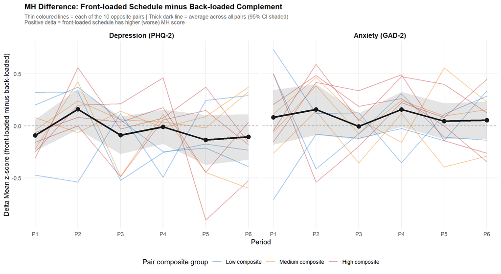

```r
flip_sched <- function(s) chartr("HL", "LH", s)

sched_meta2 <- data_analysis %>%
    filter(predictable == 1, period > 0) %>%
    distinct(schedule, vol_fl, front_loading, vol_fl_grp) %>%
    mutate(complement = flip_sched(schedule))

mh_wide <- data_analysis %>%
    filter(predictable == 1, period >= 1) %>%
    group_by(schedule, period) %>%
    summarise(
        phq2 = mean(phq2_z, na.rm = TRUE),
        gad2 = mean(gad2_z, na.rm = TRUE),
        .groups = "drop"
    )

pairs2 <- sched_meta2 %>%
    filter(schedule < complement) %>%
    left_join(sched_meta2 %>% select(schedule, fl_comp = front_loading),
        by = c("complement" = "schedule")
    ) %>%
    mutate(
        sched_A    = ifelse(front_loading >= fl_comp, schedule, complement),
        sched_B    = ifelse(front_loading >= fl_comp, complement, schedule),
        pair_label = paste0(sched_A, " vs ", sched_B)
    )

contrasts <- pairs2 %>%
    select(pair_label, sched_A, sched_B, vol_fl_grp) %>%
    left_join(mh_wide %>% rename(sched_A = schedule, phq2_A = phq2, gad2_A = gad2), by = "sched_A") %>%
    left_join(mh_wide %>% rename(sched_B = schedule, phq2_B = phq2, gad2_B = gad2),
        by = c("sched_B", "period")
    ) %>%
    mutate(
        delta_phq2 = phq2_A - phq2_B,
        delta_gad2 = gad2_A - gad2_B
    ) %>%
    tidyr::pivot_longer(
        cols = c(delta_phq2, delta_gad2),
        names_to = "outcome", values_to = "delta"
    ) %>%
    mutate(
        OutcomeLabel = ifelse(outcome == "delta_phq2", "Depression (PHQ-2)", "Anxiety (GAD-2)"),
        OutcomeLabel = factor(OutcomeLabel, levels = c("Depression (PHQ-2)", "Anxiety (GAD-2)"))
    )

avg_contrast <- contrasts %>%
    group_by(period, OutcomeLabel) %>%
    summarise(
        mean_delta = mean(delta, na.rm = TRUE),
        se_delta = sd(delta, na.rm = TRUE) / sqrt(sum(!is.na(delta))),
        .groups = "drop"
    ) %>%
    mutate(lo = mean_delta - 1.96 * se_delta, hi = mean_delta + 1.96 * se_delta)

ggplot() +
    geom_hline(yintercept = 0, linetype = "dashed", color = "gray60", linewidth = 0.4) +
    geom_line(
        data = contrasts,
        aes(x = period, y = delta, group = pair_label, color = vol_fl_grp),
        alpha = 0.4, linewidth = 0.7
    ) +
    geom_ribbon(
        data = avg_contrast,
        aes(x = period, ymin = lo, ymax = hi), fill = "gray30", alpha = 0.15
    ) +
    geom_line(
        data = avg_contrast,
        aes(x = period, y = mean_delta), color = "gray10", linewidth = 1.3
    ) +
    geom_point(
        data = avg_contrast,
        aes(x = period, y = mean_delta), color = "gray10", size = 3
    ) +
    scale_x_continuous(breaks = 1:6, labels = paste0("P", 1:6)) +
    scale_color_manual(
        values = c("Low composite" = "#1976D2", "Medium composite" = "#F57C00", "High composite" = "#C62828"),
        name   = "Pair composite group"
    ) +
    facet_wrap(~OutcomeLabel, ncol = 2) +
    labs(
        title = "MH Difference: Front-loaded Schedule minus Back-loaded Complement",
        subtitle = paste0(
            "Thin coloured lines = each of the 10 opposite pairs | ",
            "Thick dark line = average across all pairs (95% CI shaded)\n",
            "Positive delta = front-loaded schedule has higher (worse) MH score"
        ),
        x = "Period", y = "Delta Mean z-score (front-loaded minus back-loaded)"
    ) +
    theme_minimal(base_size = 11) +
    theme(
        strip.text = element_text(face = "bold", size = 11),
        panel.grid.minor = element_blank(),
        legend.position = "bottom",
        plot.title = element_text(face = "bold", size = 12),
        plot.subtitle = element_text(size = 8.5, color = "gray40")
    )
```

## 5.4 Test 3: Pair-Contrast Regression

Pool all 10 pairs x 6 periods (60 obs). Test (a) whether the mean contrast != 0, and (b) whether it trends over time.

```r
# ── Recompute contrasts (self-contained, no dependency on plot chunk) ──────────
flip_sched2 <- function(s) chartr("HL", "LH", s)

sched_meta3 <- data_analysis %>%
    filter(predictable == 1, period > 0) %>%
    distinct(schedule, vol_fl, front_loading, vol_fl_grp) %>%
    mutate(complement = flip_sched2(schedule))

mh_wide2 <- data_analysis %>%
    filter(predictable == 1, period >= 1) %>%
    group_by(schedule, period) %>%
    summarise(
        phq2 = mean(phq2_z, na.rm = TRUE),
        gad2 = mean(gad2_z, na.rm = TRUE),
        .groups = "drop"
    )

pairs3 <- sched_meta3 %>%
    filter(schedule < complement) %>%
    left_join(sched_meta3 %>% select(schedule, fl_comp = front_loading),
        by = c("complement" = "schedule")
    ) %>%
    mutate(
        sched_A    = ifelse(front_loading >= fl_comp, schedule, complement),
        sched_B    = ifelse(front_loading >= fl_comp, complement, schedule),
        pair_label = paste0(sched_A, " vs ", sched_B)
    )

contrasts2 <- pairs3 %>%
    select(pair_label, sched_A, sched_B, vol_fl_grp) %>%
    left_join(mh_wide2 %>% rename(sched_A = schedule, phq2_A = phq2, gad2_A = gad2),
        by = "sched_A"
    ) %>%
    left_join(mh_wide2 %>% rename(sched_B = schedule, phq2_B = phq2, gad2_B = gad2),
        by = c("sched_B", "period")
    ) %>%
    filter(!is.na(phq2_A), !is.na(phq2_B), !is.na(gad2_A), !is.na(gad2_B)) %>%
    mutate(
        delta_phq2 = phq2_A - phq2_B,
        delta_gad2 = gad2_A - gad2_B
    )

cat("Pairs available:", length(unique(contrasts2$pair_label)), "\n")
```

```
## Pairs available: 10
```

```r
cat("Obs (pair x period):", nrow(contrasts2), "\n\n")
```

```
## Obs (pair x period): 60
```

```r
# ── Fit models for each outcome ────────────────────────────────────────────────
fit_models <- function(delta_col) {
    df <- contrasts2 %>%
        rename(delta = !!delta_col) %>%
        mutate(period_f = factor(period))

    list(
        raw   = lm(delta ~ 1, data = df), # is mean delta != 0?
        adj   = lm(delta ~ period_f, data = df), # period-adjusted mean
        trend = lm(delta ~ period, data = df) # linear trend over time
    )
}

mods_phq2 <- fit_models("delta_phq2")
mods_gad2 <- fit_models("delta_gad2")

# ── Summary table using broom::tidy ───────────────────────────────────────────
tidy_model <- function(m, label) {
    broom::tidy(m, conf.int = TRUE) %>%
        filter(term %in% c("(Intercept)", "period")) %>%
        mutate(
            Model = label,
            term = ifelse(term == "(Intercept)", "Mean contrast", "Change per period"),
            estimate = round(estimate, 4),
            std.error = round(std.error, 4),
            statistic = round(statistic, 3),
            p.value = round(p.value, 4),
            sig = ifelse(p.value < 0.01, "***",
                ifelse(p.value < 0.05, "**",
                    ifelse(p.value < 0.10, "*", "")
                )
            )
        ) %>%
        select(Model,
            Coefficient = term, Estimate = estimate,
            SE = std.error, t = statistic, p = p.value, sig
        )
}

results_phq2 <- bind_rows(
    tidy_model(mods_phq2$raw, "PHQ-2: raw mean"),
    tidy_model(mods_phq2$adj, "PHQ-2: period-adj"),
    tidy_model(mods_phq2$trend, "PHQ-2: time trend")
)

results_gad2 <- bind_rows(
    tidy_model(mods_gad2$raw, "GAD-2: raw mean"),
    tidy_model(mods_gad2$adj, "GAD-2: period-adj"),
    tidy_model(mods_gad2$trend, "GAD-2: time trend")
)

all_results <- bind_rows(results_phq2, results_gad2)
print(knitr::kable(all_results, caption = "Pair Contrast Regression: Front-loaded minus Back-loaded Complement"))
```

```
##
##
## Table: Pair Contrast Regression: Front-loaded minus Back-loaded Complement
##
## |Model             |Coefficient       | Estimate|     SE|      t|      p|sig |
## |:-----------------|:-----------------|--------:|------:|------:|------:|:---|
## |PHQ-2: raw mean   |Mean contrast     |  -0.0453| 0.0407| -1.113| 0.2701|    |
## |PHQ-2: period-adj |Mean contrast     |  -0.0911| 0.0988| -0.923| 0.3602|    |
## |PHQ-2: time trend |Mean contrast     |   0.0425| 0.0927|  0.458| 0.6486|    |
## |PHQ-2: time trend |Change per period |  -0.0251| 0.0238| -1.054| 0.2965|    |
## |GAD-2: raw mean   |Mean contrast     |   0.0820| 0.0401|  2.045| 0.0453|**  |
## |GAD-2: period-adj |Mean contrast     |   0.0820| 0.1007|  0.814| 0.4190|    |
## |GAD-2: time trend |Mean contrast     |   0.1126| 0.0921|  1.223| 0.2263|    |
## |GAD-2: time trend |Change per period |  -0.0087| 0.0236| -0.370| 0.7127|    |
```

## 5.5 Test 4: Period-Aware Contrast — Split by Current Draw Type

The overall mean contrast (Test 3) averages across periods where the front-loaded schedule is currently receiving H draws AND periods where it receives L draws. For a pair like HHHLLL vs LLLHHH these effects cancel: early periods (front-loaded gets H) pull delta negative; late periods (front-loaded gets L) pull delta positive.

The correct test: for each pair-period observation, label whether the front-loaded schedule is currently in a HIGH draw period or LOW draw period, then compare delta across those two states. Under the income-timing hypothesis: delta_when_A_gets_H < 0 (front-loaded has more resources right now, so better MH) and delta_when_A_gets_L > 0 (reverse). The difference should be significant even if the mean across all periods is near zero.

```r
# ── Get actual draw sequence per schedule x period ────────────────────────────
draw_seq <- data_analysis %>%
    filter(predictable == 1, period >= 1) %>%
    group_by(schedule, period) %>%
    summarise(draw = round(mean(high_draw, na.rm = TRUE)), .groups = "drop")

# ── Rebuild pair contrasts with draw info ─────────────────────────────────────
flip_sched3 <- function(s) chartr("HL", "LH", s)

sched_meta4 <- data_analysis %>%
    filter(predictable == 1, period > 0) %>%
    distinct(schedule, front_loading, vol_fl_grp) %>%
    mutate(complement = flip_sched3(schedule))

pairs4 <- sched_meta4 %>%
    filter(schedule < complement) %>%
    left_join(sched_meta4 %>% select(schedule, fl_comp = front_loading),
        by = c("complement" = "schedule")
    ) %>%
    mutate(
        sched_A    = ifelse(front_loading >= fl_comp, schedule, complement),
        sched_B    = ifelse(front_loading >= fl_comp, complement, schedule),
        pair_label = paste0(sched_A, " vs ", sched_B)
    )

mh_wide3 <- data_analysis %>%
    filter(predictable == 1, period >= 1) %>%
    group_by(schedule, period) %>%
    summarise(
        phq2 = mean(phq2_z, na.rm = TRUE),
        gad2 = mean(gad2_z, na.rm = TRUE),
        .groups = "drop"
    )

contrasts3 <- pairs4 %>%
    select(pair_label, sched_A, sched_B, vol_fl_grp) %>%
    left_join(mh_wide3 %>% rename(sched_A = schedule, phq2_A = phq2, gad2_A = gad2), by = "sched_A") %>%
    left_join(mh_wide3 %>% rename(sched_B = schedule, phq2_B = phq2, gad2_B = gad2),
        by = c("sched_B", "period")
    ) %>%
    left_join(draw_seq %>% rename(sched_A = schedule, draw_A = draw), by = c("sched_A", "period")) %>%
    filter(!is.na(phq2_A), !is.na(phq2_B), !is.na(draw_A)) %>%
    mutate(
        delta_phq2 = phq2_A - phq2_B,
        delta_gad2 = gad2_A - gad2_B,
        draw_state = ifelse(draw_A == 1,
            "A gets H (front-loaded advantage)",
            "A gets L (front-loaded disadvantage)"
        )
    )

cat("Check: draw_A should flip each period within a pair (complements).\n")
```

```
## Check: draw_A should flip each period within a pair (complements).
```

```r
cat("Obs with draw_A=1:", sum(contrasts3$draw_A == 1), " | draw_A=0:", sum(contrasts3$draw_A == 0), "\n\n")
```

```
## Obs with draw_A=1: 30  | draw_A=0: 30
```

```r
# ── Mean delta by draw state ───────────────────────────────────────────────────
draw_summary <- contrasts3 %>%
    group_by(draw_state) %>%
    summarise(
        n         = n(),
        mean_phq2 = round(mean(delta_phq2, na.rm = TRUE), 4),
        se_phq2   = round(sd(delta_phq2, na.rm = TRUE) / sqrt(n()), 4),
        mean_gad2 = round(mean(delta_gad2, na.rm = TRUE), 4),
        se_gad2   = round(sd(delta_gad2, na.rm = TRUE) / sqrt(n()), 4),
        .groups   = "drop"
    )

cat("Mean contrast by draw state:\n")
```

```
## Mean contrast by draw state:
```

```r
print(knitr::kable(draw_summary, caption = "Mean delta (front-loaded minus back-loaded) by current draw type"))
```

```
##
##
## Table: Mean delta (front-loaded minus back-loaded) by current draw type
##
## |draw_state                           |  n| mean_phq2| se_phq2| mean_gad2| se_gad2|
## |:------------------------------------|--:|---------:|-------:|---------:|-------:|
## |A gets H (front-loaded advantage)    | 30|   -0.0574|   0.057|    0.0270|  0.0614|
## |A gets L (front-loaded disadvantage) | 30|   -0.0332|   0.059|    0.1369|  0.0505|
```

```r
# ── Regression: draw_state predicts delta ─────────────────────────────────────
cat("\n\n### Regression: draw state predicts pair contrast\n")
```

```
##
##
## ### Regression: draw state predicts pair contrast
```

```r
m_phq2_draw <- lm(delta_phq2 ~ draw_A + period, data = contrasts3)
m_gad2_draw <- lm(delta_gad2 ~ draw_A + period, data = contrasts3)

res_draw <- bind_rows(
    broom::tidy(m_phq2_draw) %>%
        filter(term %in% c("(Intercept)", "draw_A", "period")) %>%
        mutate(Outcome = "PHQ-2 (Depression)"),
    broom::tidy(m_gad2_draw) %>%
        filter(term %in% c("(Intercept)", "draw_A", "period")) %>%
        mutate(Outcome = "GAD-2 (Anxiety)")
) %>%
    mutate(
        term = case_when(
            term == "(Intercept)" ~ "Intercept (A gets L, period=0)",
            term == "draw_A" ~ "A gets H draw (vs L) [KEY COEFFICIENT]",
            term == "period" ~ "Period trend"
        ),
        estimate = round(estimate, 4),
        std.error = round(std.error, 4),
        statistic = round(statistic, 3),
        p.value = round(p.value, 4),
        sig = ifelse(p.value < 0.01, "***",
            ifelse(p.value < 0.05, "**",
                ifelse(p.value < 0.10, "*", "")
            )
        )
    ) %>%
    select(Outcome,
        Coefficient = term, Estimate = estimate, SE = std.error,
        t = statistic, p = p.value, sig
    )

print(knitr::kable(res_draw,
    caption = paste0(
        "Draw-state regression: does front-loaded HH have better MH ",
        "when currently receiving H vs L draw?"
    )
))
```

```
##
##
## Table: Draw-state regression: does front-loaded HH have better MH when currently receiving H vs L draw?
##
## |Outcome            |Coefficient                            | Estimate|     SE|      t|      p|sig |
## |:------------------|:--------------------------------------|--------:|------:|------:|------:|:---|
## |PHQ-2 (Depression) |Intercept (A gets L, period=0)         |   0.0996| 0.1210|  0.823| 0.4138|    |
## |PHQ-2 (Depression) |A gets H draw (vs L) [KEY COEFFICIENT] |  -0.0649| 0.0879| -0.739| 0.4630|    |
## |PHQ-2 (Depression) |Period trend                           |  -0.0321| 0.0257| -1.249| 0.2169|    |
## |GAD-2 (Anxiety)    |Intercept (A gets L, period=0)         |   0.2360| 0.1180|  2.000| 0.0503|*   |
## |GAD-2 (Anxiety)    |A gets H draw (vs L) [KEY COEFFICIENT] |  -0.1402| 0.0857| -1.636| 0.1073|    |
## |GAD-2 (Anxiety)    |Period trend                           |  -0.0240| 0.0251| -0.955| 0.3435|    |
```

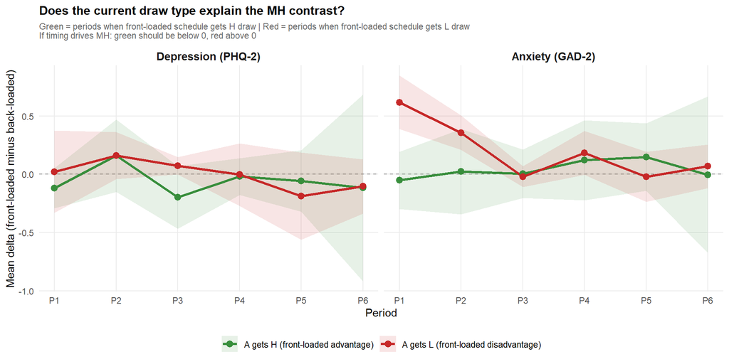

```r
# ── Visualisation: delta by period, colored by draw state ─────────────────────
contrasts3_long <- contrasts3 %>%
    tidyr::pivot_longer(
        cols = c(delta_phq2, delta_gad2),
        names_to = "outcome", values_to = "delta"
    ) %>%
    mutate(
        OutcomeLabel = ifelse(outcome == "delta_phq2",
            "Depression (PHQ-2)", "Anxiety (GAD-2)"
        ),
        OutcomeLabel = factor(OutcomeLabel,
            levels = c("Depression (PHQ-2)", "Anxiety (GAD-2)")
        )
    )

avg_by_draw <- contrasts3_long %>%
    group_by(period, draw_state, OutcomeLabel) %>%
    summarise(
        mean_d = mean(delta, na.rm = TRUE),
        se_d = sd(delta, na.rm = TRUE) / sqrt(n()),
        .groups = "drop"
    ) %>%
    mutate(lo = mean_d - 1.96 * se_d, hi = mean_d + 1.96 * se_d)

ggplot(avg_by_draw, aes(x = period, y = mean_d, color = draw_state, fill = draw_state)) +
    geom_hline(yintercept = 0, linetype = "dashed", color = "gray60", linewidth = 0.4) +
    geom_ribbon(aes(ymin = lo, ymax = hi), alpha = 0.12, color = NA) +
    geom_line(linewidth = 1.1) +
    geom_point(size = 2.8) +
    scale_x_continuous(breaks = 1:6, labels = paste0("P", 1:6)) +
    scale_color_manual(values = c(
        "A gets H (front-loaded advantage)" = "#388E3C",
        "A gets L (front-loaded disadvantage)" = "#C62828"
    )) +
    scale_fill_manual(values = c(
        "A gets H (front-loaded advantage)" = "#388E3C",
        "A gets L (front-loaded disadvantage)" = "#C62828"
    )) +
    facet_wrap(~OutcomeLabel, ncol = 2) +
    labs(
        title = "Does the current draw type explain the MH contrast?",
        subtitle = paste0(
            "Green = periods when front-loaded schedule gets H draw | ",
            "Red = periods when front-loaded schedule gets L draw\n",
            "If timing drives MH: green should be below 0, red above 0"
        ),
        x = "Period", y = "Mean delta (front-loaded minus back-loaded)", color = NULL, fill = NULL
    ) +
    theme_minimal(base_size = 11) +
    theme(
        strip.text = element_text(face = "bold", size = 11),
        panel.grid.minor = element_blank(),
        legend.position = "bottom",
        plot.title = element_text(face = "bold", size = 12),
        plot.subtitle = element_text(size = 8.5, color = "gray40")
    )
```

# 6 INCOME ROBUSTNESS CHECK: SCHEDULE SHAPE vs CURRENT DRAW

Is the positive `vol_fl` coefficient on total income a **schedule-shape effect** (i.e. the timing/volatility structure generates more income) or just **mechanically tracking the current draw** (H draw periods have higher income regardless of schedule)? We add `high_draw` as a control. If `vol_fl_std` remains significant after controlling for `high_draw`, the schedule shape has an independent income effect beyond the current-period draw.

```r
# ── Outcome sets ───────────────────────────────────────────────────────────────
# Panel A: z-score outcomes (MH) — show 3 decimal places
panel_a <- c(
    phq2_z = "Depression (PHQ-2)",
    gad2_z = "Anxiety (GAD-2)"
)

# Panel B1: raw-currency outcomes
panel_b1_raw <- c(
    "total_income_99", "total_consumption_99", "food_consumption_total_99",
    "loan_total_outstanding_99", "svg_savings_flow_99", "asset_net_99"
)
# Panel B2: count/days outcomes (small numbers — show 2 decimal places)
panel_b2_raw <- c("days_worked", "working_adults_corrected")

# Labels for panel B: use reg_labels where available, fallback to variable name
panel_b_labels_all <- c(
    reg_labels,
    loan_total_outstanding_99 = "Loan Outstanding",
    days_worked               = "Days Worked",
    working_adults_corrected  = "Working Adults"
)
mk_panel <- function(vars) {
    out <- setNames(panel_b_labels_all[vars], vars)
    out[is.na(out)] <- vars[is.na(out)]
    out
}
panel_b1 <- mk_panel(panel_b1_raw)
panel_b2 <- mk_panel(panel_b2_raw)

# ── Model fitter ───────────────────────────────────────────────────────────────
fit_rob <- function(y, spec, dat = data_reg) {
    fml <- switch(spec,
        vfl  = as.formula(paste0(y, " ~ vol_fl_std | period")),
        hd   = as.formula(paste0(y, " ~ high_draw   | period")),
        both = as.formula(paste0(y, " ~ vol_fl_std + high_draw | period"))
    )
    tryCatch(feols(fml, cluster = ~hh_id, data = dat), error = function(e) NULL)
}

build_mods <- function(outcomes_named) {
    mods <- list()
    for (y in names(outcomes_named)) {
        nm <- outcomes_named[[y]]
        mods[[paste0(nm, " | vol_fl")]] <- fit_rob(y, "vfl")
        mods[[paste0(nm, " | high_draw")]] <- fit_rob(y, "hd")
        mods[[paste0(nm, " | both")]] <- fit_rob(y, "both")
    }
    Filter(Negate(is.null), mods)
}

coef_map_rob <- c(
    "vol_fl_std" = "vol_fl (std.) — schedule shape",
    "high_draw"  = "High draw (current period)"
)
notes_rob <- paste0(
    "Predictable group, periods 1-6. Period FE. SEs clustered at HH. ",
    "Each outcome: (1) vol_fl only; (2) high_draw only; (3) both. ",
    "Key test: if vol_fl survives in 'both', schedule shape has an independent ",
    "effect beyond mechanically tracking the current-period draw."
)

# ── Panel A: Mental Health ─────────────────────────────────────────────────────
cat("### Panel A: Mental Health outcomes\n\n")
```

### 6.0.1 Panel A: Mental Health outcomes

```r
modelsummary(build_mods(panel_a),
    coef_map = coef_map_rob, fmt = 3,
    stars    = c("*" = 0.1, "**" = 0.05, "***" = 0.01),
    gof_omit = "AIC|BIC|Log|RMSE|Std",
    title    = "Panel A — MH: Is vol_fl Effect Independent of Current Draw?",
    notes    = notes_rob, output = "html"
)
```

Panel A — MH: Is vol_fl Effect Independent of Current Draw?

|  | Depression (PHQ-2) \| vol_fl | Depression (PHQ-2) \| high_draw | Depression (PHQ-2) \| both | Anxiety (GAD-2) \| vol_fl | Anxiety (GAD-2) \| high_draw | Anxiety (GAD-2) \| both |
| --- | --- | --- | --- | --- | --- | --- |
| vol_fl (std.) — schedule shape | 0.000 |  | 0.000 | 0.030 |  | 0.030 |
|  | (0.024) |  | (0.024) | (0.026) |  | (0.026) |
| High draw (current period) |  | -0.011 | -0.011 |  | -0.052 | -0.052 |
|  |  | (0.039) | (0.039) |  | (0.039) | (0.039) |
| Num.Obs. | 2239 | 2239 | 2239 | 2239 | 2239 | 2239 |
| R2 | 0.030 | 0.030 | 0.030 | 0.049 | 0.048 | 0.049 |
| R2 Adj. | 0.028 | 0.028 | 0.027 | 0.046 | 0.046 | 0.046 |
| R2 Within | 0.000 | 0.000 | 0.000 | 0.001 | 0.001 | 0.002 |
| R2 Within Adj. | -0.000 | -0.000 | -0.001 | 0.000 | 0.000 | 0.001 |
| FE: period | X | X | X | X | X | X |

* p < 0.1, ** p < 0.05, *** p < 0.01  
Predictable group, periods 1-6. Period FE. SEs clustered at HH. Each outcome: (1) vol_fl only; (2) high_draw only; (3) both. Key test: if vol_fl survives in 'both', schedule shape has an independent effect beyond mechanically tracking the current-period draw.

```r
cat("\n\n")
```

```r
# ── Panel B1: Currency outcomes ───────────────────────────────────────────────
cat("### Panel B: Economic outcomes (currency, rounded to integers)\n\n")
```

### 6.0.2 Panel B: Economic outcomes (currency, rounded to integers)

```r
modelsummary(build_mods(panel_b1),
    coef_map = coef_map_rob, fmt = "%.0f",
    stars    = c("*" = 0.1, "**" = 0.05, "***" = 0.01),
    gof_omit = "AIC|BIC|Log|RMSE|Std",
    title    = "Panel B1 — Currency Outcomes: Is vol_fl Effect Independent of Current Draw?",
    notes    = notes_rob, output = "html"
)
```

Panel B1 — Currency Outcomes: Is vol_fl Effect Independent of Current Draw?

|  | Total Income \| vol_fl | Total Income \| high_draw | Total Income \| both | Total Consumption \| vol_fl | Total Consumption \| high_draw | Total Consumption \| both | Food Consumption \| vol_fl | Food Consumption \| high_draw | Food Consumption \| both | Loan Outstanding \| vol_fl | Loan Outstanding \| high_draw | Loan Outstanding \| both | Savings Flow \| vol_fl | Savings Flow \| high_draw | Savings Flow \| both | Net Assets \| vol_fl | Net Assets \| high_draw | Net Assets \| both |
| --- | --- | --- | --- | --- | --- | --- | --- | --- | --- | --- | --- | --- | --- | --- | --- | --- | --- | --- |
| vol_fl (std.) — schedule shape | 28** |  | 28** | -6 |  | -6 | -8 |  | -8 | -15 |  | -15 | -8 |  | -8 | -5 |  | -5 |
|  | (12) |  | (12) | (18) |  | (18) | (13) |  | (13) | (12) |  | (12) | (6) |  | (6) | (4) |  | (4) |
| High draw (current period) |  | 5 | 6 |  | -12 | -12 |  | -6 | -6 |  | -26 | -26 |  | 23 | 23 |  | -4 | -4 |
|  |  | (18) | (18) |  | (20) | (20) |  | (15) | (15) |  | (19) | (19) |  | (22) | (22) |  | (6) | (6) |
| Num.Obs. | 2246 | 2246 | 2246 | 2246 | 2246 | 2246 | 2246 | 2246 | 2246 | 2246 | 2246 | 2246 | 2092 | 2092 | 2092 | 2246 | 2246 | 2246 |
| R2 | 0.025 | 0.022 | 0.025 | 0.110 | 0.110 | 0.110 | 0.076 | 0.076 | 0.076 | 0.034 | 0.034 | 0.035 | 0.002 | 0.003 | 0.003 | 0.020 | 0.019 | 0.020 |
| R2 Adj. | 0.023 | 0.019 | 0.022 | 0.108 | 0.108 | 0.108 | 0.074 | 0.073 | 0.073 | 0.031 | 0.031 | 0.032 | -0.000 | -0.000 | -0.000 | 0.017 | 0.016 | 0.017 |
| R2 Within | 0.004 | 0.000 | 0.004 | 0.000 | 0.000 | 0.000 | 0.000 | 0.000 | 0.000 | 0.001 | 0.001 | 0.002 | 0.000 | 0.001 | 0.001 | 0.001 | 0.000 | 0.001 |
| R2 Within Adj. | 0.003 | -0.000 | 0.003 | -0.000 | -0.000 | -0.001 | -0.000 | -0.000 | -0.000 | 0.001 | 0.000 | 0.001 | -0.000 | 0.000 | 0.000 | 0.000 | -0.000 | 0.000 |
| FE: period | X | X | X | X | X | X | X | X | X | X | X | X | X | X | X | X | X | X |

* p < 0.1, ** p < 0.05, *** p < 0.01  
Predictable group, periods 1-6. Period FE. SEs clustered at HH. Each outcome: (1) vol_fl only; (2) high_draw only; (3) both. Key test: if vol_fl survives in 'both', schedule shape has an independent effect beyond mechanically tracking the current-period draw.

```r
cat("\n\n")
```

```r
# ── Panel B2: Labor outcomes ───────────────────────────────────────────────────
cat("### Panel C: Labor outcomes (days / count, 2 d.p.)\n\n")
```

### 6.0.3 Panel C: Labor outcomes (days / count, 2 d.p.)

```r
modelsummary(build_mods(panel_b2),
    coef_map = coef_map_rob, fmt = 2,
    stars    = c("*" = 0.1, "**" = 0.05, "***" = 0.01),
    gof_omit = "AIC|BIC|Log|RMSE|Std",
    title    = "Panel C — Labor Outcomes: Is vol_fl Effect Independent of Current Draw?",
    notes    = notes_rob, output = "html"
)
```

Panel C — Labor Outcomes: Is vol_fl Effect Independent of Current Draw?

|  | Days Worked \| vol_fl | Days Worked \| high_draw | Days Worked \| both | Working Adults \| vol_fl | Working Adults \| high_draw | Working Adults \| both |
| --- | --- | --- | --- | --- | --- | --- |
| vol_fl (std.) — schedule shape | -0.07 |  | -0.07 | -0.00 |  | -0.00 |
|  | (0.13) |  | (0.14) | (0.02) |  | (0.02) |
| High draw (current period) |  | 0.37* | 0.37* |  | -0.02 | -0.02 |
|  |  | (0.21) | (0.22) |  | (0.03) | (0.03) |
| Num.Obs. | 2246 | 2246 | 2246 | 2246 | 2246 | 2246 |
| R2 | 0.039 | 0.040 | 0.040 | 0.051 | 0.051 | 0.051 |
| R2 Adj. | 0.037 | 0.037 | 0.037 | 0.049 | 0.049 | 0.048 |
| R2 Within | 0.000 | 0.001 | 0.001 | 0.000 | 0.000 | 0.000 |
| R2 Within Adj. | -0.000 | 0.001 | 0.000 | -0.000 | -0.000 | -0.001 |
| FE: period | X | X | X | X | X | X |

* p < 0.1, ** p < 0.05, *** p < 0.01  
Predictable group, periods 1-6. Period FE. SEs clustered at HH. Each outcome: (1) vol_fl only; (2) high_draw only; (3) both. Key test: if vol_fl survives in 'both', schedule shape has an independent effect beyond mechanically tracking the current-period draw.

## 6.1 Decomposing vol_fl: Volatility vs Front-loading vs Current Draw

`vol_fl` is a composite of two schedule features. We decompose it to understand *which component drives each outcome*: **volatility** (`n_switches` — how often income switches between H and L) or **front-loading** (`front_loading` — whether H draws cluster early). We also add `high_draw` to show whether the effect survives after accounting for the current-period income draw.

**Five specifications per outcome:**

| Column | Regressors | Question |
| --- | --- | --- |
| (1) vol_fl | composite only | Baseline |
| (2) switches | n_switches only | Does volatility drive outcome? |
| (3) front_load | front_loading only | Does timing/sequencing drive outcome? |
| (4) decomp | switches + front_loading | Which dominates when both included? |
| (5) full | switches + front_loading + high_draw | Does schedule shape survive current draw? |

```r
# ── Standardise component variables ───────────────────────────────────────────
data_reg2 <- data_reg %>%
    mutate(
        sw_std = as.numeric(scale(n_switches)),
        fl_std = as.numeric(scale(front_loading))
    )

# ── Outcomes to decompose (key outcomes only to keep table readable) ───────────
decomp_outcomes <- c(
    phq2_z             = "Depression (PHQ-2)",
    gad2_z             = "Anxiety (GAD-2)",
    total_income_99    = "Total Income",
    total_consumption_99 = "Total Consumption",
    loan_total_outstanding_99 = "Loan Outstanding",
    svg_savings_flow_99 = "Savings Flow",
    days_worked        = "Days Worked"
)

# ── Fitter for each spec ───────────────────────────────────────────────────────
fit_decomp <- function(y, spec) {
    fml <- switch(spec,
        vfl    = as.formula(paste0(y, " ~ vol_fl_std               | period")),
        sw     = as.formula(paste0(y, " ~ sw_std                   | period")),
        fl     = as.formula(paste0(y, " ~ fl_std                   | period")),
        decomp = as.formula(paste0(y, " ~ sw_std + fl_std          | period")),
        full   = as.formula(paste0(y, " ~ sw_std + fl_std + high_draw | period"))
    )
    tryCatch(feols(fml, cluster = ~hh_id, data = data_reg2), error = function(e) NULL)
}

specs   <- c("vfl", "sw", "fl", "decomp", "full")
sp_sfx  <- c("(1) vol_fl", "(2) switches", "(3) front_load", "(4) decomp", "(5) full")

build_decomp <- function(outcomes_named) {
    mods <- list()
    for (y in names(outcomes_named)) {
        nm <- outcomes_named[[y]]
        for (i in seq_along(specs)) {
            mods[[paste0(nm, " | ", sp_sfx[i])]] <- fit_decomp(y, specs[i])
        }
    }
    Filter(Negate(is.null), mods)
}

coef_decomp <- c(
    "vol_fl_std" = "vol_fl composite (std.)",
    "sw_std"     = "N switches / volatility (std.)",
    "fl_std"     = "Front-loading (std.)",
    "high_draw"  = "High draw (current period)"
)
notes_decomp <- paste0(
    "All models: predictable group, periods 1-6, period FE, SEs clustered at HH. ",
    "sw_std = standardised n_switches (volatility); fl_std = standardised front_loading. ",
    "Column (5) adds the current-period draw dummy to test whether schedule shape ",
    "effects persist beyond mechanical income tracking."
)

# ── Panel A: MH ───────────────────────────────────────────────────────────────
cat("### Panel A: Mental Health — Volatility vs Front-loading Decomposition\n\n")
```

### 6.1.1 Panel A: Mental Health — Volatility vs Front-loading Decomposition

```r
modelsummary(
    build_decomp(decomp_outcomes[c("phq2_z", "gad2_z")]),
    coef_map = coef_decomp, fmt = 3,
    stars    = c("*" = 0.1, "**" = 0.05, "***" = 0.01),
    gof_omit = "AIC|BIC|Log|RMSE|Std",
    title    = "MH: Volatility vs Front-loading",
    notes    = notes_decomp, output = "html"
)
```

MH: Volatility vs Front-loading

|  | Depression (PHQ-2) \| (1) vol_fl | Depression (PHQ-2) \| (2) switches | Depression (PHQ-2) \| (3) front_load | Depression (PHQ-2) \| (4) decomp | Depression (PHQ-2) \| (5) full | Anxiety (GAD-2) \| (1) vol_fl | Anxiety (GAD-2) \| (2) switches | Anxiety (GAD-2) \| (3) front_load | Anxiety (GAD-2) \| (4) decomp | Anxiety (GAD-2) \| (5) full |
| --- | --- | --- | --- | --- | --- | --- | --- | --- | --- | --- |
| vol_fl composite (std.) | 0.000 |  |  |  |  | 0.030 |  |  |  |  |
|  | (0.024) |  |  |  |  | (0.026) |  |  |  |  |
| N switches / volatility (std.) |  | 0.005 |  | 0.005 | 0.005 |  | 0.012 |  | 0.012 | 0.012 |
|  |  | (0.024) |  | (0.024) | (0.024) |  | (0.026) |  | (0.026) | (0.026) |
| Front-loading (std.) |  |  | -0.015 | -0.015 | -0.015 |  |  | 0.035 | 0.035 | 0.035 |
|  |  |  | (0.025) | (0.025) | (0.025) |  |  | (0.027) | (0.028) | (0.028) |
| High draw (current period) |  |  |  |  | -0.011 |  |  |  |  | -0.051 |
|  |  |  |  |  | (0.039) |  |  |  |  | (0.039) |
| Num.Obs. | 2239 | 2239 | 2239 | 2239 | 2239 | 2239 | 2239 | 2239 | 2239 | 2239 |
| R2 | 0.030 | 0.030 | 0.031 | 0.031 | 0.031 | 0.049 | 0.048 | 0.049 | 0.049 | 0.050 |
| R2 Adj. | 0.028 | 0.028 | 0.028 | 0.028 | 0.027 | 0.046 | 0.045 | 0.046 | 0.046 | 0.046 |
| R2 Within | 0.000 | 0.000 | 0.000 | 0.000 | 0.000 | 0.001 | 0.000 | 0.001 | 0.001 | 0.002 |
| R2 Within Adj. | -0.000 | -0.000 | -0.000 | -0.001 | -0.001 | 0.000 | -0.000 | 0.001 | 0.000 | 0.001 |
| FE: period | X | X | X | X | X | X | X | X | X | X |

* p < 0.1, ** p < 0.05, *** p < 0.01  
All models: predictable group, periods 1-6, period FE, SEs clustered at HH. sw_std = standardised n_switches (volatility); fl_std = standardised front_loading. Column (5) adds the current-period draw dummy to test whether schedule shape effects persist beyond mechanical income tracking.

```r
cat("\n\n")
```

```r
# ── Panel B: Economic outcomes ────────────────────────────────────────────────
cat("### Panel B: Economic outcomes — Volatility vs Front-loading Decomposition\n\n")
```

### 6.1.2 Panel B: Economic outcomes — Volatility vs Front-loading Decomposition

```r
modelsummary(
    build_decomp(decomp_outcomes[c("total_income_99", "total_consumption_99",
                                   "loan_total_outstanding_99", "svg_savings_flow_99")]),
    coef_map = coef_decomp, fmt = "%.0f",
    stars    = c("*" = 0.1, "**" = 0.05, "***" = 0.01),
    gof_omit = "AIC|BIC|Log|RMSE|Std",
    title    = "Economic: Volatility vs Front-loading",
    notes    = notes_decomp, output = "html"
)
```

Economic: Volatility vs Front-loading

|  | Total Income \| (1) vol_fl | Total Income \| (2) switches | Total Income \| (3) front_load | Total Income \| (4) decomp | Total Income \| (5) full | Total Consumption \| (1) vol_fl | Total Consumption \| (2) switches | Total Consumption \| (3) front_load | Total Consumption \| (4) decomp | Total Consumption \| (5) full | Loan Outstanding \| (1) vol_fl | Loan Outstanding \| (2) switches | Loan Outstanding \| (3) front_load | Loan Outstanding \| (4) decomp | Loan Outstanding \| (5) full | Savings Flow \| (1) vol_fl | Savings Flow \| (2) switches | Savings Flow \| (3) front_load | Savings Flow \| (4) decomp | Savings Flow \| (5) full |
| --- | --- | --- | --- | --- | --- | --- | --- | --- | --- | --- | --- | --- | --- | --- | --- | --- | --- | --- | --- | --- |
| vol_fl composite (std.) | 28** |  |  |  |  | -6 |  |  |  |  | -15 |  |  |  |  | -8 |  |  |  |  |
|  | (12) |  |  |  |  | (18) |  |  |  |  | (12) |  |  |  |  | (6) |  |  |  |  |
| N switches / volatility (std.) |  | 27** |  | 27** | 27** |  | -13 |  | -12 | -12 |  | -16 |  | -16 | -16 |  | -7 |  | -7 | -7 |
|  |  | (12) |  | (12) | (12) |  | (20) |  | (20) | (20) |  | (14) |  | (14) | (14) |  | (6) |  | (6) | (6) |
| Front-loading (std.) |  |  | 12 | 13 | 13 |  |  | 24 | 24 | 24 |  |  | -5 | -6 | -6 |  |  | -6 | -6 | -6 |
|  |  |  | (13) | (13) | (13) |  |  | (18) | (18) | (18) |  |  | (12) | (12) | (12) |  |  | (5) | (5) | (5) |
| High draw (current period) |  |  |  |  | 6 |  |  |  |  | -11 |  |  |  |  | -26 |  |  |  |  | 23 |
|  |  |  |  |  | (18) |  |  |  |  | (20) |  |  |  |  | (19) |  |  |  |  | (22) |
| Num.Obs. | 2246 | 2246 | 2246 | 2246 | 2246 | 2246 | 2246 | 2246 | 2246 | 2246 | 2246 | 2246 | 2246 | 2246 | 2246 | 2092 | 2092 | 2092 | 2092 | 2092 |
| R2 | 0.025 | 0.025 | 0.022 | 0.026 | 0.026 | 0.110 | 0.111 | 0.112 | 0.113 | 0.113 | 0.034 | 0.034 | 0.033 | 0.034 | 0.035 | 0.002 | 0.002 | 0.002 | 0.002 | 0.003 |
| R2 Adj. | 0.023 | 0.023 | 0.020 | 0.023 | 0.022 | 0.108 | 0.108 | 0.110 | 0.110 | 0.109 | 0.031 | 0.031 | 0.030 | 0.031 | 0.032 | -0.000 | -0.001 | -0.001 | -0.001 | -0.001 |
| R2 Within | 0.004 | 0.004 | 0.001 | 0.004 | 0.004 | 0.000 | 0.001 | 0.002 | 0.003 | 0.003 | 0.001 | 0.001 | 0.000 | 0.001 | 0.002 | 0.000 | 0.000 | 0.000 | 0.000 | 0.001 |
| R2 Within Adj. | 0.003 | 0.003 | 0.000 | 0.003 | 0.003 | -0.000 | 0.000 | 0.002 | 0.002 | 0.001 | 0.001 | 0.001 | -0.000 | 0.000 | 0.001 | -0.000 | -0.000 | -0.000 | -0.001 | -0.000 |
| FE: period | X | X | X | X | X | X | X | X | X | X | X | X | X | X | X | X | X | X | X | X |

* p < 0.1, ** p < 0.05, *** p < 0.01  
All models: predictable group, periods 1-6, period FE, SEs clustered at HH. sw_std = standardised n_switches (volatility); fl_std = standardised front_loading. Column (5) adds the current-period draw dummy to test whether schedule shape effects persist beyond mechanical income tracking.

```r
cat("\n\n")
```

```r
# ── Panel C: Labor ────────────────────────────────────────────────────────────
cat("### Panel C: Labor — Volatility vs Front-loading Decomposition\n\n")
```

### 6.1.3 Panel C: Labor — Volatility vs Front-loading Decomposition

```r
modelsummary(
    build_decomp(decomp_outcomes["days_worked"]),
    coef_map = coef_decomp, fmt = 2,
    stars    = c("*" = 0.1, "**" = 0.05, "***" = 0.01),
    gof_omit = "AIC|BIC|Log|RMSE|Std",
    title    = "Labor: Volatility vs Front-loading",
    notes    = notes_decomp, output = "html"
)
```

Labor: Volatility vs Front-loading

|  | Days Worked \| (1) vol_fl | Days Worked \| (2) switches | Days Worked \| (3) front_load | Days Worked \| (4) decomp | Days Worked \| (5) full |
| --- | --- | --- | --- | --- | --- |
| vol_fl composite (std.) | -0.07 |  |  |  |  |
|  | (0.13) |  |  |  |  |
| N switches / volatility (std.) |  | -0.12 |  | -0.12 | -0.12 |
|  |  | (0.12) |  | (0.12) | (0.12) |
| Front-loading (std.) |  |  | -0.04 | -0.05 | -0.04 |
|  |  |  | (0.14) | (0.14) | (0.14) |
| High draw (current period) |  |  |  |  | 0.36* |
|  |  |  |  |  | (0.22) |
| Num.Obs. | 2246 | 2246 | 2246 | 2246 | 2246 |
| R2 | 0.039 | 0.039 | 0.039 | 0.039 | 0.041 |
| R2 Adj. | 0.037 | 0.037 | 0.036 | 0.036 | 0.037 |
| R2 Within | 0.000 | 0.001 | 0.000 | 0.001 | 0.002 |
| R2 Within Adj. | -0.000 | 0.000 | -0.000 | -0.000 | 0.000 |
| FE: period | X | X | X | X | X |

* p < 0.1, ** p < 0.05, *** p < 0.01  
All models: predictable group, periods 1-6, period FE, SEs clustered at HH. sw_std = standardised n_switches (volatility); fl_std = standardised front_loading. Column (5) adds the current-period draw dummy to test whether schedule shape effects persist beyond mechanical income tracking.